# Density-(In)Dependence, Point Equilibria, and Linear Stability

# 1 Introduction

The goals of this weeks lab are the following:

- Introduce the use of ordinary differential equations and the deSolve package for population modeling
- Review the basics of density-independent and density-dependent population models
- Introduce ideas regarding equilibria, stability, and chaos
- Introduce the Generalized Lotka-Volterra model as a simple extension of logistic growth
- Gain further proficiency with constructing, interrogating, and visualizing population models in R

New Models: exponential growth model; logistic growth model; generalized Lotka-Volterra model New Tools: numerical simulation with ODE solvers; identification of equilibria; linear stability analysis; birfurcation diagrams

# 2 ODEs and deSolve

Recall that one decision we must make when constructing a population model is whether our population grows **discretely** or **continuously** . Today, we will mostly assume that our populations grow continuously (though we will take a detour to examine characteristics of discrete-time logistic growth). When we model continuously growing populations, we typically use **differential equations** which define the **instantaneous growth rate** of a population. Note that this is the growth rate of the population under a given set of values for the **state variables** (typically population densities at a given time) and assuming a set of values for the underlying population **parameters** . This is different than the **intrinsic growth rate** which is a parameter describing the per capita growth rate, often assuming no density-dependence.

When we use **ordinary differential equations (ODEs)** to simulate population dynamics, we want to calculate the instantaneous growth rate of a population *practically* continuously across some time frame, calculating a new population size from the old population size and the current instantaneous growth rate. I say *practically* continuously because what we actually do is calculate the new population size at some very small interval throughout the time frame. For each interval, we take the integral of the differential equation to get the growth during that very small interval. Because these equations quickly become difficult to find the integral of **analytically** like you may have done if you took a calculus class, we instead find the integral **numerically** . We use algorithms called **ODE solvers** that try to approximate the integral. If you haven’t already, please install the “deSolve” package which contains the solvers that we will use in this class.

We will walk through the implementation of these solvers through deSolve in the following section using the exponential growth equation.

# 3 Density-Independent Growth

So where do we even begin with building population models? That task may sound daunting if you’re new to modeling or population ecology. There are so many physiological, ecological, and evolutionary processes that determine the growth of any given population! Well, to start, let’s use a model that ignores all of that. Cutting away unnecessary detail is one of the most important skills as an ecologist, so let’s cut away nearly all ecological details by using a simple exponential model for population growth. The **exponential model** is a simple model that will serve as the basis for many other models we’ll see throughout this course.

Recall that the size of a population growing exponentially can be described with the following equation:

$$N_t = N_0e^{rt}$$

Remember though that we often prefer to work with differential equations (mostly because the exponential growth equation is one of the few population models that we can define as an equation… so we’ll need to get comfortable with differential equations quickly). Taking the derivative of the previous equation, we get:

$$\frac{dN}{dt} = rN$$

Although we could use the $N_t = N_0e^{rt}$ equation to directly calculate the growth of a population over time, let’s use this simple population growth model to introduce using differential equation solvers using the $\frac{dN}{dt} = rN$ equation. Soon, we will learn about population models for which no closed form solution exists.

The first step to simulating population growth using deSolve is to define the population model in the form of a function:

```r
exp_mod <- function(time, state, parameters) {
  with(as.list(c(state, parameters)), { # using these objects ...
    dN <- r * N # the differential equation for N
    list(c(dN)) # return the rate of change
  })
}
```

Recall that when we define our own functions, we need to tell R what inputs the function needs and then we need to describe what to do with those inputs. Here, we want our function to take time (which will be supplied to the function later), some vector of **initial values** for our state variables (in this case, just $N$), and some vector of parameters (in this case, just $r$). Our function is then going to use those vectors (the `with()` function keeps our code nice and tidy when we have lots of state variables or parameters), calculate the instantaneous growth rate ($dN/dt$) and then return those values.

Perhaps predictably, we then need to define our initial values, parameters, and the time points that we want to record the values of the population size for:

```r
init_vals <- c(N = 2)
pars <- c(r = .35)
t <- seq(from = 1, to = 25, by = 0.1)
```

Now that we’ve defined our initial values, parameters, and our sequence of time points, let’s implement our ODE solvers using the `ode()` function. We’ll feed it our initial values as `y`, our time sequence as `times`, our function as `func`, and our parameters as `parms`.

```r
output <- ode(y = init_vals, times = t, func = exp_mod, parms = pars)
head(output)
```

```
##      time        N
## [1,]  1.0 2.000000
## [2,]  1.1 2.071242
## [3,]  1.2 2.145020
## [4,]  1.3 2.221423
## [5,]  1.4 2.300550
## [6,]  1.5 2.382495
```

As you can see, the `ode()` function spits out a data frame of our state variables across our specific time sequence. Now we can take this data frame and plot the values, creating a plot of the population’s time series:

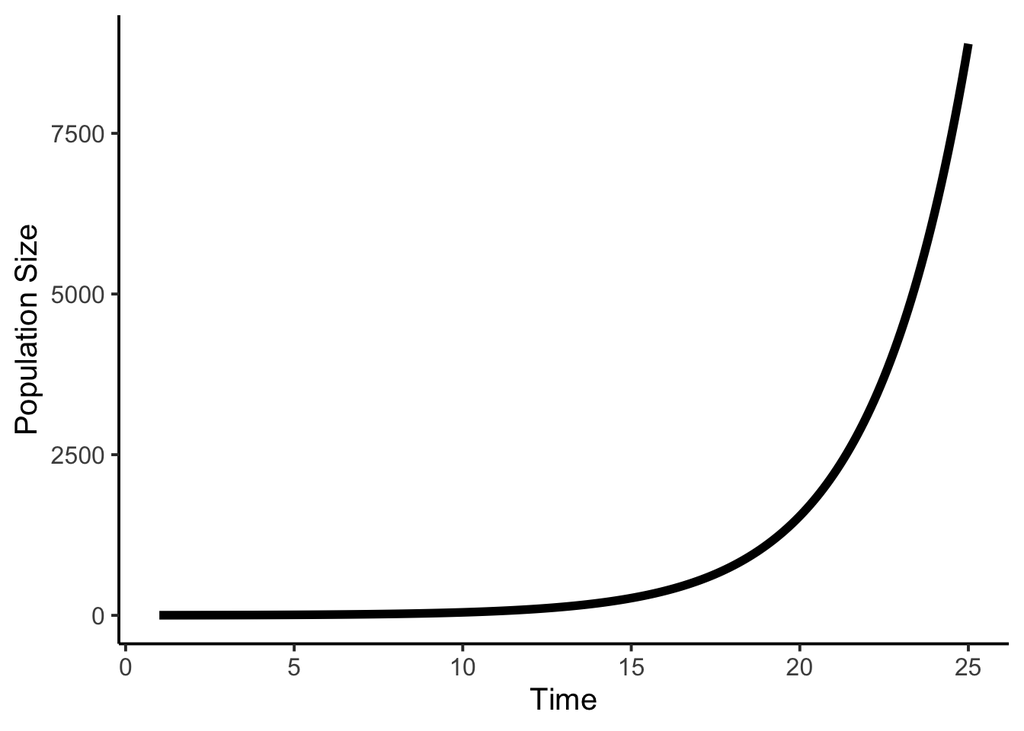

```r
output %>%
  ggplot(aes(x = time, y = N)) +
  geom_line(size = 2) +
  theme_classic(base_size = 15) +
  xlab("Time") + ylab("Population Size")
```

Looks like exponential growth to me!

**A note on the use of simulations in population modeling:** Recall that once we’ve defined a population model, there are three broad categories that we’ll learn about in this class to interrogate our model: *Parameter Estimation*, *Analysis*, and *Simulation-Based Methods*. We have now learned how to simulate from continuous, deterministic population models using ODE solvers. In this assignment, we are principally using simulations to visualize population dynamics and make some fairly shallow inference. In later assignments, we will learn how to make more robust and interesting inference about population dynamics using simulations. Like each of these three categories of methods, simulation-based methods have pro’s and con’s and we often complement simulation-based methods with parameter estimation and/or analysis.

Simulation-based methods really shine when we are working with more complex models. When we work with stochastic models or models with much more complexity, it becomes very difficult to perform mathematical analysis. In these cases, numerical simulations of the population dynamics can serve as an alternative to gaining intuition through analysis. There are a few tradeoffs, however. Firstly, simulation-based methods can become quite computationally intensive, depending on how complex the model is and also what specific numerical methods we’re using to simulate these dynamics. Secondly, the results from simulation-based methods aren’t always as clean as the results from analytical methods. Partly because analytical methods have historically been the preferred method for theoretical investigations of population dynamics, there is a rich literature regarding the methods and interpretation of the results for the analysis sof population models. The analogous literature for simulation-based methods, while quickly growing, still lags behind. We will discuss analytical methods a bit more in this assignment, and will revisit the pro’s and con’s of each of these three categories of methods throughout this course.

Exercise 1

**Compile the above example into your own function which plots an exponentially growing population. Your function should include the population growth rate, the initial value of the population, and the number of time steps (ie the duration of the time series) as arguments. Use your function to plot a ten time point time series of a population with a growth rate of 0.1 and an initial population size of 2.**

A central goal of population ecology is to understand how certain population parameters impact population growth. Often, when we introduce a new population model, we will ask that you explore the role of the underlying parameters in mediating population growth.

Exercise 2

**Simulate the population growth across 5 years of three populations having intrinsic growth rates of .5, 1, and 1.5. Have each population start with an initial population size of 1. Display these population’s time series as a line graph with different colors for each population.**

These models may work fine for describing **density-independent growth** of populations that reproduce continuously, but we may wish to describe the growth of an annual plant or a univoltine insect. To do this, recall the following formula for **geometric population growth** :

$$N_t = N_0\lambda^t$$

We can calculate the difference in the population size between two time steps using the following equation:

$$N_{t+1} = \lambda N_t$$

Note that, in practice, this is not a differential equation. Ecologically relevant values do not exist between time steps. Thus, we would not use deSolve to simulate this discrete growth. Instead, we might use what is called a **loop** . A loop iterates a process, and different types of loops iterate the process differently. Among the most commonly used loops is the *for loop* which iterates a process for a set of values. For example, we might wish to iterate the calculation of $N_{t+1}$ based off of $N_t$ for some number of years. The code to do this might look like the following:

```r
# define our parameter(s) and initial value(s)
N_0 <- 1
lambda <- 1.2

# define the length of our simulation (AKA the number of iterations)
iter <- 25

# initialize a vector of values for N_t
Ns <- c(N_0)
for(i in 1:iter){ # i is an index which takes on the values of 1:iter
  Ns[i+1] <- lambda * Ns[i] # calculate and store our new value for N_{t+1}
}
Ns
```

```
##  [1]  1.000000  1.200000  1.440000  1.728000  2.073600  2.488320  2.985984
##  [8]  3.583181  4.299817  5.159780  6.191736  7.430084  8.916100 10.699321
## [15] 12.839185 15.407022 18.488426 22.186111 26.623333 31.948000 38.337600
## [22] 46.005120 55.206144 66.247373 79.496847 95.396217
```

When we use for loops, we specify an index (here, `i`) and a vector of values that `i` takes on during the loop (here, `1:iter`). The code within the squiggly brackets is run first with `i` as the first value in the vector. the code is then run again with `i` as the next value, and so on for each value in the vector. For loops are kinda tricky for a lot of folks when they first learn to code, so don’t worry if this feels confusing now. We’ll gain more practice with for loops throughout this quarter, especially when we work with discrete time population models.

Exercise 3

**As review, describe what values of $\lambda$ and $r$ indicate negative, no, and positive population growth.**

Recall that although not equivalent, $\lambda$ and $r$ are mathematically related with the following equation:

$$\lambda = e^r$$

# 4 Density-Dependent Growth

Alright, so populations do not grow exponentially indefinitely. Does this mean that the exponential model is wrong? Remember that *all models are wrong*. In lieu of “correct” models, let’s instead consider when a given model can be useful. Certainly there are some systems that can be described adequately (for a certain goal) with an exponential growth model, but more commonly we may want to incorporate a near universal ecological process: density-dependence. A still quite simple but much more useful model, then, would be the logistic growth model.

Recall that the instantaneous growth rate of a population that is growing logistically can be described as the following differential equation:

$$dN/dt = rN(1 - N/K)$$

To gain intuition about logistic growth, we’ll first play around with some simulations. Then, we’ll take an analytical approach and introduce some ideas about equilibria and stability.

To simulate the dynamics of a logistically growing population, let’s define the logistic growth function that we’ll feed into the `ode()` function.

```r
log_mod <- function(time, state, parameters) {
  with(as.list(c(state, parameters)), { # using these objects ...
    dN <- r * N * (1 - N/K) # the differential equation for N
    list(c(dN)) # return the rate of change
  })
}
```

Now, let’s define the parameters of the equation ($r$ and $K$), the initial values for the state variable ($N$), and the time vector that we would like to save the values of the state variables.

```r
init_vals <- c(N = 2)
pars <- c(r = .5, K = 50)
t <- seq(from = 1, to = 25, by = 0.1)
```

Now, we can run the ODE solver and simulate the time series of our logistically growing population. Let’s also make a pretty graph while we’re at it.

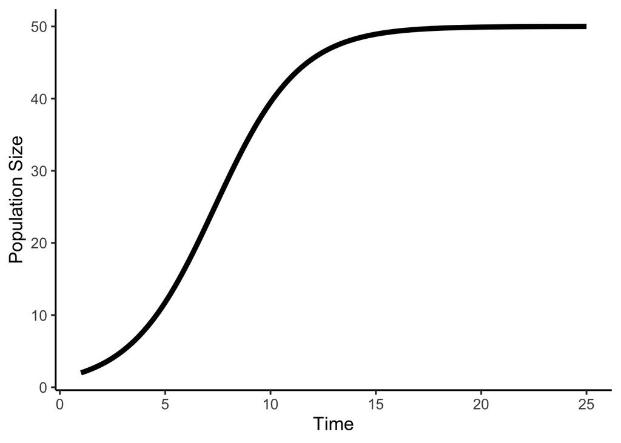

```r
output <- ode(y = init_vals, times = t, func = log_mod, parms = pars)
output %>%
  ggplot(aes(x = time, y = N)) +
  geom_line(size = 2) +
  theme_classic(base_size = 15) +
  xlab("Time") + ylab("Population Size")
```

Lookin’ good!

Exercise 4

**Compile the above example into your own function which plots a logistically growing population. Your function should include the intrinsic growth rate, the carrying capacity,the initial value of the population, and the number of time steps (ie the duration of the time series) as arguments. Use your function to plot a twenty time point time series of a population with a growth rate of 0.1, a carrying capacity of 100, and an initial population size of 2.**

## 4.1 Analysis of the Logistic Growth Model

If we wish to understand the fundamental behavior of a population, assuming some relatively simple population model, analytical methods are typically the preferred approach. **Analysis** often includes using tools from various disciplines of math such as calculus and linear algebra, and many of the results of analytical methods are relatively straight forward (and omit biases introduced through decisions involved in simulation-based methods). Even more importantly, these methods can often be implemented on pen and paper or simple computers, which is why these have been some of the more popular methods in population ecology pre-modern computers.

Some of the most common analytical methods have to do with identifying **equilibria** and characterizing the **stability** around those equilibria. Let’s introduce some of these methods by first defining equilibira. When ecologists discuss equilibria, we are referring to the typical behavior of a system. In population ecology, we often use equilibrium to describe the typical population sizes of the components of a system (e.g. different species, different groups of individuals within a population, different alleles in a population). *Take a moment to consider what the equilibrium/a might be for the logistic growth model.*

So how do we identify equilibria? Recall that differential equations describe the instantaneous population growth rate as a function of the value of the state variable(s) (typically population sizes). So if we want to identify the population sizes at which populations typically stay at, we should look for population sizes which produce an instantaneous growth rate of $0$. Thus, to identify equilibria points (we’ll discuss other types of equilibria besides point equilibria throughout this course) of a population model, defined as a differential equation, we set the differential equation equal to $0$ and solve for the population sizes. For the logistic growth model defined above, there are two equilibria: a **trivial equilibrium** of $N = 0$ and a more interesting equilibrium of $N = K$. Thus, we often refer to the carrying capacity as the equilibrium abundance of a logistically growing population. This math is relatively simple to do by hand, but as equations get more complicated, we might resort to root solver algorithms that either identify the exact roots when given an equation and some parameter values or that provide a symbolic (parameter agnostic) expression of the roots. R has some built in functions for finding exact roots, such as `uniroot()` and `polyroot()`. Additional packages have more sophisticated numerical solvers, and some packages also enable symbolic solutions but these packages are a bit more involved.

Exercise 5

**This discussion of identifying equilibria is focused principally on theoretical methods. Brainstorm and describe at least two reasons why you think that identifying equilibria in the real world (i.e. *empirically*) would be difficult.**

Exercise 6

**Let’s take a moment to visualize what we just discussed (another check in addition to hand calculations and programmatic operations). Consider a population that is growing logistically with an intrinsic growth rate of $0.5$ and a carrying capacity of $100$. Plot the instantaneous growth rate $dN/dt$ as a function of the population size $N$ for a population with an intrinsic growth rate of 1 and another population wuth an intrinsic growth rate of 2. Make sure that these curves are on the same graph to facilitate comparison.**

Exercise 7

**Using your graph from Exercise 6, describe how you could identify the equilibria points.**

Exercise 8

**Do the equilibria change when we change the intrinsic growth rate of the logistically growing population? Does anything else change?**

We now know how to identify point equilibria, but just knowing the equilibria of a population doesn’t tell us much. The logistic growth model contains two equilibria, so what are some ways that we can meaningfully describe variation in our equilibria? One characteristic that varies between different equilibria is *stability*. This term can be used in a few different ways, but for now what we mean by *stability* is whether or not a population will return to a given equilibrium if it is nudged away from it. This is rather important as ecologists are often concerned with what disturbances will do to a system. If a forest is at equilibrium, will it return to that same equilibrium after a windstorm? Will the introduction of an invasive predator shift the dynamics of a food web from their pre-invaded equilibrium dynamics? Again, in practice, this is a really challenging question to address for real populations, but we can build up intuition and insights from analysis of more simple, deterministic models.

One technique to characterize the stability of equilibria is called **linear stability analysis** . We call it linear stability analysis because we attempt to reduce the information contained in our *nonlinear* dynamical systems model into a simple *linear* equation that we can evaluate at the equilibrium. What this looks like exactly depends on the complexity of the population model, but generally the goal is to evaluate whether (infinitesimally) small nudges away from an equilibrium point results in the return to that equilibrium or whether this pushes the population further away from the original equilibrium point. We might also use linear stability analysis to compare how strong the pull toward a stable equilibrium is relative to other stable equilibria. Let’s walk through this process using the logistic growth model from above.

**A note on math behind a linear stability analysis:** So we said that our goal in conducting a linear stability analysis is to identify the dynamics of a population model at it’s equilibrium, and we do this by simplifying our nonlinear population model into some linear form. To do this ‘linearization’ at a given point, we can use a very important tool from mathematics called *Taylor expansion*. The goal of a Taylor expansion is to approximate a function by using information about the function’s value, slope, and curvature at a given point. We do this by taking a bunch of derivatives, sequentially adding more and more detail to our approximation and leading to an increasingly close approximation. If all we want, though, is to linearize a function at a point, we simply need to find the slope of the function at that point by taking the function’s first derivative. This is called the first order term of the Taylor series.

It is not important that you understand Taylor expansions for this class. For linear stability analysis, we only care about the first derivative (the slope) because it tells us whether small changes near an equilibrium grow (unstable) or shrink (stable). That means that we will only ever need to find first derivatives of functions. In the case of one-dimensional dynamical systems, this means evaluating the derivative of the dynamical system model at it’s equilibria.

For systems with multiple variables (like populations of interacting species), we use a tool called the *Jacobian matrix*. The Jacobian is a collection of partial derivatives, with each entry describing how one variable influences another near the equilibrium. To understand the stability of these systems, we use a mathematical operation called *eigenanalysis*, which distills the information in the Jacobian into key values (*eigenvalues*). These values tell us whether the equilibrium is stable or unstable (and also whether the system will oscillate, but we’ll get to that later).

Don’t worry if this is all a bit much right now. You do not need to know anything about Taylor expansions for this course. You also will never need to take any derivatives or do an eigenanalysis by hand. For this course, *how* you do these mathematical processes is less important than *why* you do them, and we will often ignore the mathematical detail in favor of learning how to implement these tools in R. We will also learn more about the Jacobian and eigenanalysis in future worksheets.

We have already identified the equilibria of this model, so let’s now figure out whether $N = 0$ and $N = K$ are stable equilibria or not. To do this, we will find the derivative of our differential equation at each of our equilibria. Recall that, in this case, the derivative of the logistic growth differential equation is a new equation which calculates the speed and direction of change in the instantaneous growth rate equation as a function of the population size. Thus, the derivative evaluated at our equilibria characterizes whether the growth rate increases or decreases (and how fast it does so) from zero at $N = 0$ and $N = K$. The derivative is:

$$d^2N/dt^2 = r(1-\frac{N}{K})-\frac{N r}{K}$$

*Take a moment to evaluate this equation when $N = 0$ and when $N = K$.* Notice that the intrinsic growth rate is in this equation, so while it does not affect the location of the equilibria, it does influence the dynamics around each of the two equilibria. Evaluated at $N = 0$, the derivative is $r$. What does this mean though? Well, at $N = 0$, the slope of the tangent line is positive. Thus, an infinitesimally small nudge to the right will lead to $dN/dt > 0$ and the population will grow away from $0$. If it were biologically possible, an infinitesimally small nudge to the left will lead to $dN/dt < 0$ and the population would decrease away from $0$. Conversely, when $N = K$, the derivative is $-r$ so the slope of the tangent line is negative. Thus, an infinitesimally small nudge to the right of $K$ will lead to $dN/dt < 0$ and the population will decrease back to $K$. An infinitesimally small nudge to the left will lead to $dN/dt > 0$ and the population will increase back to $K$. What we’ve just described is an **unstable equilibrium** at $0$ and a **stable equilibrium** at $K$. For a differential equation with just one state variable of interest, determining whether an equilibrium is stable or not is as simple as evaluating the derivative of the differential equation at the equilibrium and determining whether this value is positive or negative.

```r
log_deriv <- deriv(expression(1 * N * (1 - N / 100)), "N") # get derivative

# evaluate derivative at equilibria and store as vector
sens_values <- c(zero = attr(eval(log_deriv, envir = list(N = 0)), "gradient"),
                 k = attr(eval(log_deriv, envir = list(N = 100)), "gradient"))

# display
sens_values
```

```
## zero    k
##    1   -1
```

Exercise 9

**When we perform a linear stability analysis on a one-dimensional population, the magnitude of the derivative evaluated at the equilibrium describes how stable or unstable an equilibirum is and can be used to compare across equilibrium and models. Based on this information, what is the relationship between the intrinsic growth rate and the stability at carrying capacity for a logistically growing population?**

Exercise 10

**Does the exponential growth model from above contain any equilibria? If so, which of the equilibria are stable and which are not?**

## 4.2 Discrete Logistic Growth & Chaos

Keep in mind that while we’ve primarily been working with models for continuously growing populations during this worksheet, we can define a discrete analogue to the logistic growth equation that might better suit organisms who’s populations growth discretely. The difference equation for such a model might look like:

$$N_{t+1} - N_t = \lambda * N_t (1 - N_t/K)$$

As we did with our geometric growth model above, we can simulate the population dynamics for a discrete, logistically growing population using the following for loop:

```r
# define our parameter(s) and initial value(s)
N_0 <- 1
lambda <- 1
K <- 100

# define the length of our simulation (AKA the number of iterations)
iter <- 25

# initialize a vector of values for N_t
Ns <- c(N_0)
for(i in 1:iter){ # i is an index which takes on the values of 1:iter
  delta_N <- lambda * Ns[i] * (1 - Ns[i]/K) # calculate difference
  Ns[i+1] <- Ns[i] +  delta_N # calculate new pop size
}
Ns
```

```
##  [1]   1.000000   1.990000   3.940399   7.725531  14.854223  27.501966
##  [7]  47.440351  72.374833  92.368502  99.417602  99.996608 100.000000
## [13] 100.000000 100.000000 100.000000 100.000000 100.000000 100.000000
## [19] 100.000000 100.000000 100.000000 100.000000 100.000000 100.000000
## [25] 100.000000 100.000000
```

Let’s graph these values. Perhaps we should try to emphasize the discrete growth by ditching our solid curve and adopting points and a smaller dashed line to show the general trend.

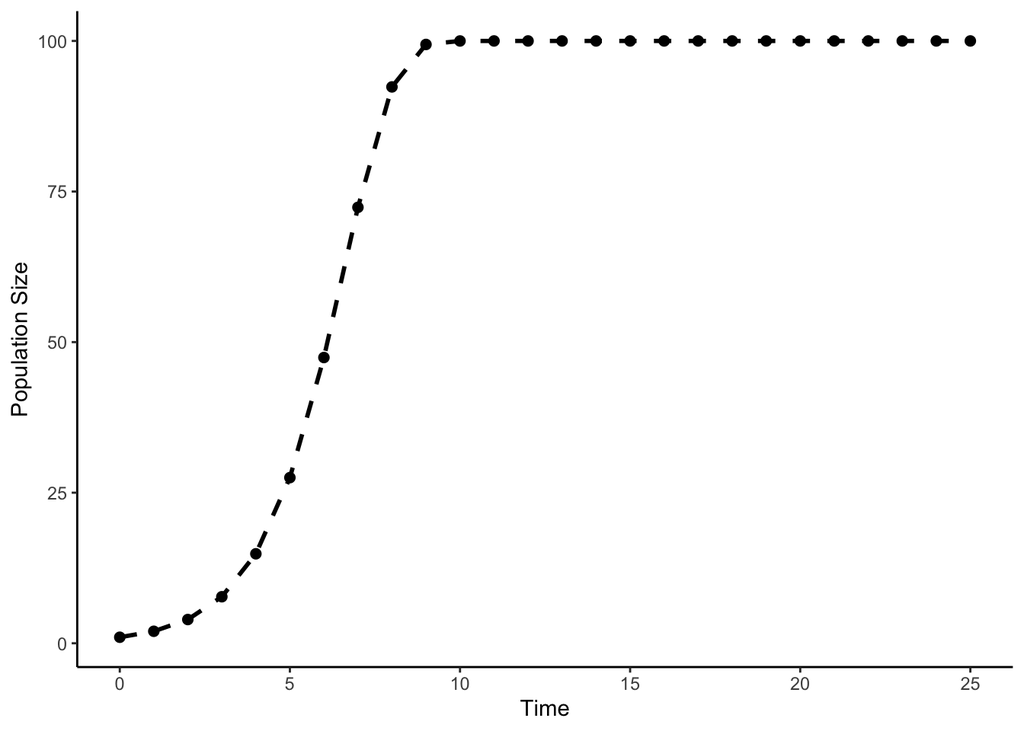

```r
cbind.data.frame(N = Ns, t = 0:iter) %>%
  ggplot(aes(t, N)) +
  geom_point(size = 2) + geom_line(size = 1, linetype = "dashed") +
  theme_classic() + xlab("Time") + ylab("Population Size")
```

Looks qualitatively similar to the continuous logistic growth we’ve worked with above! Let’s do a more formal comparison between the continuous and discrete models. Let’s also compare these models under a range of values for the intrinsic growth rate… just for fun. We’ll have you do that in the next exercise.

Exercise 11

**Simulate the growth of a continuous, logistically growing population and a discrete, logistically growing population, each with three different values for $r$: $r = 0.05$, $r = 0.5$, and $r = 1$ (remember that our discrete logistic growth model is not parameterized in terms of $r$). For each of these models, keep the carrying capacity constant at $100$ and keep the initial population size constant at $1$. Then, plot these six time series with different colors for each value of $r$ and faceted by whether the model is continuous or discrete. There are many ways to facet, but you may use `facet_wrap()` if you are using `ggplot()` or you may try out the package `patchwork` which helps arrange multiple plots.**

Exercise 12

# 5 Generalized Lotka-Volterra

So far, we have explore a lovely baseline model for population growth, the exponential growth model. We have also explored a still quite simple, but remarkably more realistic model that incorporates density-dependence, the logistic growth model. The last model that we will explore in this worksheet moves past density-dependence in single populations and incoporates a more complex form of density-dependence: **species interactions** . Although this is not a common pedagological trajectory in most population ecology textbooks to introduce species interactions so soon, we would like to equip you early with the power to not only explore the dynamics of single populations, but to use population models to study whole communities. In fact, some portion of community ecology employs population models to study the dynamics of communities. This should make some sense as communities are made up of populations.

The **generalized Lotka-Volterra (gLV)** model is a versatile model that is used to explore the population dynamics of many different, co-occurring populations that may or may not interact with one another. With a few assumptions, we can use this model to explore predator-prey interactions, competition, mutualisms, commensalisms, etc. As long as we feel comfortable reducing a species interaction into some linear dependence of population growth on interacting species’ densities, then we can use the gLV.

First, let’s introduce a new parameterization of the logistic growth model. Above, we parameterized the logistic growth model in terms of the carrying capacity $K$, but what does $K$ mean? Imposing a carrying capacity suggests that there is some negative density-dependence. Mechanistically, this could arise from direct or indirect competition between individuals, but either way we can reduce this down to a parameter that describes the per-capita effect of individuals on the population growth rate. We can call this parameter $\alpha$. It should be intuitive that there is a negative relationship between the strength of competition, $\alpha$, and the carrying capacity $K$. In fact, the carrying capacity is the inverse of the intraspecific competition coefficient. If we chose to represent negative-density dependence as negative values of $\alpha$ (some folks choose to represent the strength of competition as positive values of $\alpha$; it’s always good to check), then we can say that $\alpha = -1/K$. Thus, our new parameterization of the logistic growth equation becomes:

$$\frac{dN}{dt} = rN(1 + \alpha N)$$

Now that we have a parameter that represents intraspecific density-dependence, it’s a simple extension to define parameters that represent interspecific density-dependence. In such cases, we might define an **interaction matrix** $\textbf{A}$ where the rows (often denoted as $i$) of this matrix represent the affected species and the columns of this matrix (often denoted as $j$) represent the affecting species. Thus, some entry of $\textbf{A}$ can be called $\alpha_{ij}$ and represents the per-capita effect of species $j$ on species $i$’s instantaneous growth rate. A gLV defines the instantaneous growth rate of species $i$ as a linear combination of the co-occurring species densities $N_j$ and their respective interaction coefficients $\alpha_{ij}$:

$$\frac{dN_i}{dt} = r_iN_i(1 + \sum_{j = 1}^S\alpha_{ij}N_j)$$

where $i$ can equal $j$. $S$ is the total number of species, and the $\sum$ operator tells us to take the sum of all of the terms held within it (actually, it’s just a for loop where we keeping adding new values of $N_j\alpha_{ij}$). So now we have a dynamical systems model which has a unique differential equation for each species. You could also think about it (or code it) as a single vector-valued differential equation.

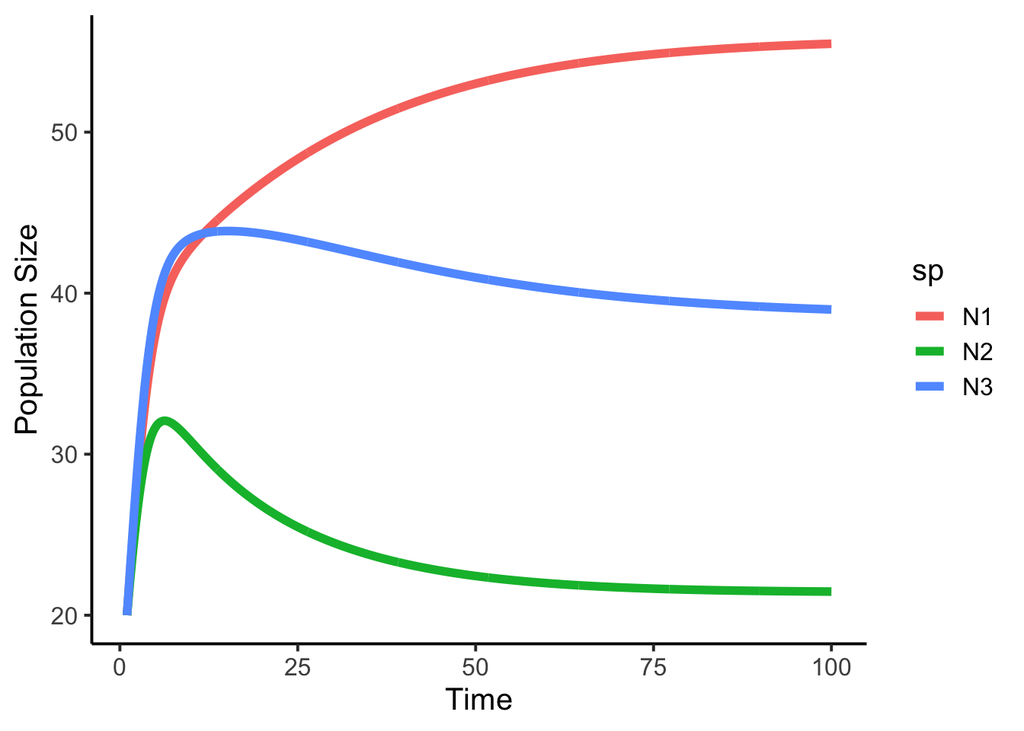

```r
# define the model to feed into ode()
gLV_mod <- function(time, state, parameters) {
  with(as.list(c(state, parameters)), { # using these objects ...
    dN1 <- r1*N1*(1 - (N1*alpha11 + N2*alpha12 + N3*alpha13)) # sp 1
    dN2 <- r2*N2*(1 - (N1*alpha21 + N2*alpha22 + N3*alpha23)) # sp 1
    dN3 <- r3*N3*(1 - (N1*alpha31 + N2*alpha32 + N3*alpha33)) # sp 1
    list(c(dN1, dN2, dN3)) # return the rate of change
  })
}

# define our parameters, initial values, and time sequence
init_vals <- c(N1 = 20, N2 = 20, N3 = 20)
pars <- c(r1 = 0.6, r2 = 0.55, r3 = 0.65,
          alpha11 = 0.01, alpha12 = 0.008, alpha13 = 0.007,
          alpha21 = 0.0085, alpha22 = 0.011, alpha23 = 0.0075,
          alpha31 = 0.009, alpha32 = 0.007, alpha33 = 0.009)
t <- seq(from = 1, to = 100, by = 0.1)

# simulate the dynamics
output <- ode(y = init_vals, times = t, func = gLV_mod, parms = pars)

# plot
output %>%
  as.data.frame() %>%
  pivot_longer(cols = c(N1, N2, N3), names_to = "sp", values_to = "N") %>%
  ggplot(aes(x = time, y = N, color = sp)) +
  geom_line(size = 2) +
  theme_classic(base_size = 15) +
  xlab("Time") + ylab("Population Size")
```

Neat! Looks like all species settle at positive values by the end of the simulation. We might say that all three species coexist with one another. In fact, these sorts of models are used frequently to study a core question in ecology: Why do competing species coexist with one another? These models have also been used to ask many, many other interesting questions in community ecology. We will work more with gLVs later in the course, and in future worksheets we will learn how to conduct a linear stability analysis of such multivariate dynamical systems models.

Exercise 13

**Thus far, we have primarily focused on negative density dependence, but what about positive density-dependence? Using our $\alpha$ parameterization of the logistic growth equation, simulate the dynamics of a population with positive density-dependence by using a positive value of $\alpha$.**

Exercise 14

**Generally, do you think that positive density-dependence *stabilizes* or *destabilizes* system dynamics?**